# Cannonball Data Cleaning and Diagnostics

### 3. Checks for other idiosyncracies?

It’s probably worth writing this into a function as well. I should probably do this before I implement high-level checks. Ideas for things I might need to check are: **Miscodes**. Misses that are actually hits, Hits that are actually misses, etc. **Odd numbers of trials** Participants bailing early on the task, getting stuck somewhere, etc.

```r
cannon_data <- check_irreg(cannon_data) #check for any mistaken hits
irreg_plot_hit <- cannon_data %>% filter(grepl("CHECK_HIT", Irreg)) %>% select(subject, cond, blocknum, trialnum, catch_miss, angmu, placementAngle, outcome, Abs_PE, angleup, angledown, shield_size, Irreg )
irreg_plot_miss <- cannon_data %>% filter(grepl("CHECK_MISS", Irreg)) %>% select(subject, cond, blocknum, trialnum, catch_miss, angmu, placementAngle, outcome, Abs_PE, angleup, angledown, shield_size, Irreg )
irreg_plot_NA <- cannon_data %>% filter(grepl("CHECK_NA", Irreg)) %>% select(subject, cond, blocknum, trialnum, catch_miss, angmu, placementAngle, outcome, Abs_PE, angleup, angledown, shield_size, Irreg)
```

### 4. Create Table of Summary statistics

```r
obj <- cannon_data %>% group_by(subject, cond, blocknum, totalearnings) %>%
  summarise(obscount = n(), avg_PE = mean(Abs_PE, na.rm = TRUE),
            dist_mean = mean(PE_angmu,na.rm = TRUE),
            percent_caught = max(cannonballs_caught/max(trialnum)),
            percent_noresp = (sum(outcomeindex == 1)/max(trialnum))) %>%
  arrange(subject,totalearnings) %>% group_by(subject) %>% mutate(taskearnings = max(totalearnings)) %>% mutate(Avg_overall_PE = mean(avg_PE, na.rm = TRUE)) %>% ungroup()
save(obj, cannon_data, file = "Cannonball_Pilot_Example_Perfect_Data.Rdata")

colormatrix <- ifelse(obj$percent_noresp >= .2, wes_palette("Cavalcanti1")[c(1)], "white") ##potentially save these as bad_blocks vector


  tab <- obj %>% flextable() %>% bg(j = 1:10, bg=colormatrix)


sink("/dev/null")
tab
```

| subject | cond | blocknum | totalearnings | obscount | avg_PE | dist_mean | percent_caught | percent_noresp | taskearnings | Avg_overall_PE |
| --- | --- | --- | --- | --- | --- | --- | --- | --- | --- | --- |
| 364 | ODDBALL | 1 | 7.0 | 60 | 47.70814 | 27.373115 | 0.3500000 | 0.00000000 | 95.0 | 34.45289 |
| 364 | ODDBALL | 2 | 17.5 | 60 | 28.20098 | 11.497697 | 0.5500000 | 0.00000000 | 95.0 | 34.45289 |
| 364 | ODDBALL | 3 | 34.0 | 60 | 29.20829 | 19.296747 | 0.3333333 | 0.00000000 | 95.0 | 34.45289 |
| 364 | ODDBALL | 4 | 44.0 | 60 | 29.19695 | 11.981920 | 0.3833333 | 0.00000000 | 95.0 | 34.45289 |
| 364 | CHANGEPOINT | 1 | 60.0 | 60 | 35.41543 | 29.752510 | 0.4666667 | 0.00000000 | 95.0 | 34.45289 |
| 364 | CHANGEPOINT | 2 | 74.0 | 60 | 34.42547 | 27.038611 | 0.3333333 | 0.00000000 | 95.0 | 34.45289 |
| 364 | CHANGEPOINT | 3 | 84.0 | 60 | 37.20315 | 35.118380 | 0.3666667 | 0.00000000 | 95.0 | 34.45289 |
| 364 | CHANGEPOINT | 4 | 95.0 | 60 | 34.26472 | 26.664867 | 0.3333333 | 0.00000000 | 95.0 | 34.45289 |
| 400 | CHANGEPOINT | 1 | 6.0 | 60 | 34.76671 | 31.982583 | 0.4000000 | 0.00000000 | 96.5 | 31.76133 |
| 400 | CHANGEPOINT | 2 | 18.0 | 60 | 33.54090 | 31.866902 | 0.3500000 | 0.00000000 | 96.5 | 31.76133 |
| 400 | CHANGEPOINT | 3 | 28.5 | 60 | 34.41095 | 29.638546 | 0.3500000 | 0.00000000 | 96.5 | 31.76133 |
| 400 | CHANGEPOINT | 4 | 39.0 | 60 | 30.43282 | 27.020370 | 0.5000000 | 0.00000000 | 96.5 | 31.76133 |
| 400 | ODDBALL | 1 | 57.5 | 60 | 27.19565 | 14.791119 | 0.4833333 | 0.00000000 | 96.5 | 31.76133 |
| 400 | ODDBALL | 2 | 72.0 | 60 | 33.96318 | 14.135910 | 0.4500000 | 0.00000000 | 96.5 | 31.76133 |
| 400 | ODDBALL | 3 | 85.5 | 60 | 28.13848 | 10.921029 | 0.3666667 | 0.00000000 | 96.5 | 31.76133 |
| 400 | ODDBALL | 4 | 96.5 | 60 | 31.64196 | 14.181792 | 0.4000000 | 0.00000000 | 96.5 | 31.76133 |
| 455 | CHANGEPOINT | 1 | 5.5 | 60 | 42.44487 | 39.487840 | 0.4000000 | 0.00000000 | 107.5 | 32.26254 |
| 455 | ODDBALL | 1 | 6.0 | 60 | 25.82192 | 7.806403 | 0.6000000 | 0.00000000 | 107.5 | 32.26254 |
| 455 | CHANGEPOINT | 2 | 17.5 | 23 | 37.31251 | 28.291352 | 0.3684211 | 0.26315789 | 107.5 | 32.26254 |
| 455 | CHANGEPOINT | 3 | 17.5 | 1 |  |  | 7.0000000 | 1.00000000 | 107.5 | 32.26254 |
| 455 | ODDBALL | 2 | 24.0 | 60 | 30.48086 | 10.746947 | 0.5500000 | 0.00000000 | 107.5 | 32.26254 |
| 455 | ODDBALL | 3 | 40.5 | 60 | 37.08033 | 22.420291 | 0.3166667 | 0.00000000 | 107.5 | 32.26254 |
| 455 | ODDBALL | 4 | 50.0 | 60 | 33.82529 | 16.553933 | 0.4000000 | 0.00000000 | 107.5 | 32.26254 |
| 455 | CHANGEPOINT | 1 | 67.0 | 60 | 28.57125 | 21.485818 | 0.4000000 | 0.00000000 | 107.5 | 32.26254 |
| 455 | CHANGEPOINT | 2 | 79.0 | 60 | 29.41493 | 24.332750 | 0.4833333 | 0.00000000 | 107.5 | 32.26254 |
| 455 | CHANGEPOINT | 3 | 93.5 | 60 | 34.09523 | 30.436619 | 0.4666667 | 0.00000000 | 107.5 | 32.26254 |
| 455 | CHANGEPOINT | 4 | 107.5 | 60 | 23.57821 | 16.248584 | 0.4500000 | 0.00000000 | 107.5 | 32.26254 |
| 576 | ODDBALL | 1 | 6.0 | 60 | 46.60105 | 33.727181 | 0.2333333 | 0.00000000 | 91.0 | 35.00859 |
| 576 | ODDBALL | 2 | 13.0 | 60 | 29.77153 | 22.231551 | 0.3500000 | 0.00000000 | 91.0 | 35.00859 |
| 576 | ODDBALL | 3 | 23.5 | 60 | 37.68574 | 19.452241 | 0.3166667 | 0.00000000 | 91.0 | 35.00859 |

[output cut: 53 more lines]

```r
sink();
```

### 5. Reaction time data

**Figure 1**. Below is a histogram of all reaction time data.

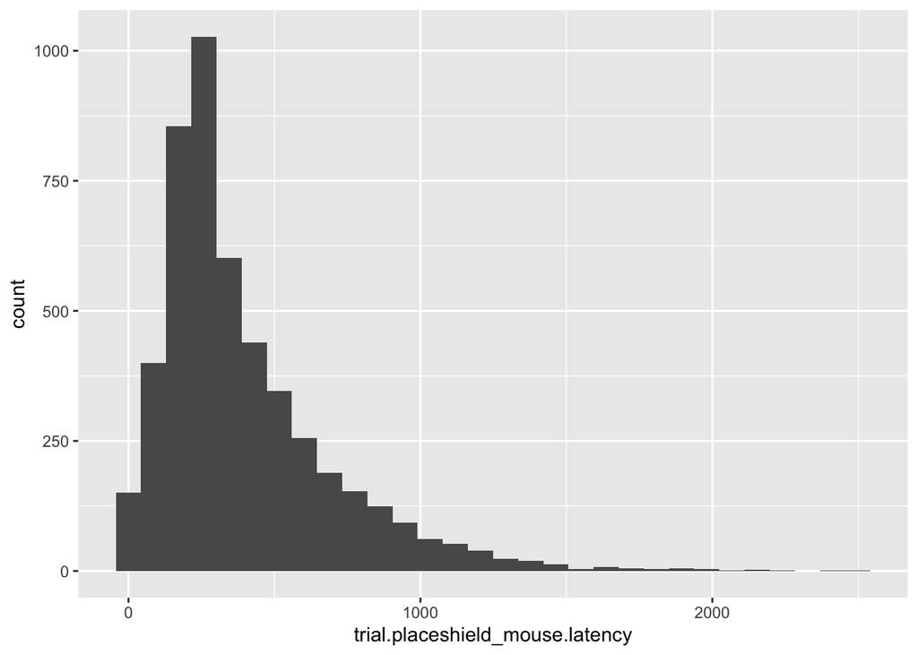

```
## # A tibble: 1 x 1
##    mean
##   <dbl>
## 1  396.
```

```r
Hist_outliers <- ggplot(cannon_data, aes(x=trial.placeshield_mouse.latency)) + geom_histogram()
Mean_cleaned <- cannon_data %>% ungroup () %>% filter(!trial.placeshield_mouse.latency == 2500) %>% summarise(mean = mean(trial.placeshield_mouse.latency))
Hist_outliers; Mean_cleaned
```

### 6. Graphical Respresentations by subject

````r
library(ggplot2)
subjects <- as.character(unique(cannon_data$subject))
# template <- c(
#     "### OddballPE {{nm}}\n",
#     "```{r, echo = FALSE}\n",
#     "ggplot(cannon_data[cannon_data$subject == '{{nm}}', ], aes(x=trialnum, y=Abs_PE, color = catch_miss)) + geom_point() + geom_vline(aes(xintercept = changepoint, color = 'Oddball'))+ scale_color_manual(values = (wes_palette('Cavalcanti1')[c(2,5,1,4)])) +
#      xlab('Trial Number') + ylab('Response Type') + ggtitle({{nm}}) +
#      facet_wrap(~blocknum)\n",
#     "```\n",
#     "\n"
#   )
#
# plots <- lapply(
#   unique(subjects),
#   function(nm) knitr::knit_expand(text = template)
# )
````

```r
oddball_PE <- list();changepoint_PE <- list();oddball_DM <- list(); changepoint_DM <- list();

for (i in subjects) {
  o <- cannon_data %>% dplyr::filter(subject == i & cond == "ODDBALL")
  oddball_PE <- ggplot(o, aes(x=trialnum, y=Abs_PE, color = catch_miss)) +
     geom_point() +
     geom_vline(aes(xintercept = changepoint, color = "Oddball")) + scale_color_manual(values = (wes_palette("Cavalcanti1")[c(2,5,1,4)])) +
     xlab("Trial Number") + ylab("Response Type") + ggtitle(i) +
     facet_wrap(~blocknum)
  oddball_PE[[i]] <- oddball_PE

  oddball_DM <- ggplot(o, aes(x=trialnum, y=PE_angmu, color = catch_miss)) +
     geom_point() +
     geom_vline(aes(xintercept = changepoint, color = "Oddball")) + scale_color_manual(values = (wes_palette("Cavalcanti1")[c(2,5,1,4)])) +
     xlab("Trial Number") + ylab("Response Type") + ggtitle(i) +
     facet_wrap(~blocknum)
   oddball_DM[[i]] <- oddball_DM

  c <- cannon_data %>% dplyr::filter(subject == i & cond == "CHANGEPOINT")
  change_point_PE <- ggplot(c,aes(x=trialnum, y=Abs_PE, color = catch_miss)) + geom_point() +
     geom_vline(aes(xintercept = changepoint, color = "Changepoint")) + scale_color_manual(values = (wes_palette("Cavalcanti1")[c(4,2,5,1)]))  +
     xlab("Trial Number") + ylab("Response Type") + ggtitle(i) +
     facet_wrap(~blocknum)
  changepoint_PE[[i]] <- changepoint_PE

 change_point_DM <- ggplot(c, aes(x=trialnum, y=PE_angmu, color = catch_miss)) +
   geom_point() +
   geom_vline(aes(xintercept = changepoint, color = "Changepoint")) + scale_color_manual(values = (wes_palette("Cavalcanti1")[c(4,2,1,5)]))  +
      xlab("Trial Number") + ylab("Response Type") + ggtitle(i) +
     facet_wrap(~blocknum)

  changepoint_DM[[i]] <- changepoint_DM


}

# for (i in subjects) {
#   o <- cannon_data %>% dplyr::filter(subject == i & cond == "ODDBALL")
#
# c <- cannon_data %>% dplyr::filter(subject == i & cond == "CHANGEPOINT")

#
# }
```